# Ecological trends in moth communities (Geometridae, Lepidoptera) along a complete rainforest elevation gradient in Papua New Guinea - Toko - Insect Conservation and Diversity - Wiley Online Library

[figure not shown]

ORIGINAL ARTICLE

Open Access

# Ecological trends in moth communities (Geometridae, Lepidoptera) along a complete rainforest elevation gradient in Papua New Guinea

[Pagi S. Toko](https://resjournals.onlinelibrary.wiley.com/authored-by/Toko/Pagi+S.),

[Bonny Koane](https://resjournals.onlinelibrary.wiley.com/authored-by/Koane/Bonny),

[Kenneth Molem](https://resjournals.onlinelibrary.wiley.com/authored-by/Molem/Kenneth),

[Scott E. Miller](https://resjournals.onlinelibrary.wiley.com/authored-by/Miller/Scott+E.),

[Vojtech Novotny](https://resjournals.onlinelibrary.wiley.com/authored-by/Novotny/Vojtech),

First published: 23 June 2023

https://doi.org/10.1111/icad.12663

Editor: Alan Stewart and Associate Editor: Steve Yanoviak

## Abstract

1. The tropical rainforest elevation gradients, extending from lowlands to treeline, often represent global maxima of biodiversity and are models for community studies.
2. We surveyed geometrid moths along a complete rainforest gradient from 200 to 3700 m asl. in Papua New Guinea. The 16,424 moths collected with light traps represented 1102 species, a high diversity for such system. We demonstrated the importance of molecular data for taxonomy as COI sequences (DNA barcodes) changed the definition of 19% of morphological species.
3. The abundance of geometrids did not change with elevation while their species richness peaked at 1200 m asl. The mid-elevation diversity peak is a common, but poorly understood, pattern for geometrids. It was best explained by the species richness of the vegetation. At the same time, the community was exposed to opposing trends in abiotic favourability (decreasing temperature) and biotic favourability (decreasing predation by ants, birds and bats) with elevation, potentially contributing to such unimodal trends in species richness.
4. Beta diversity of communities separated by 500 m elevation increased with increasing elevation, reflecting decreasing mean elevational range of species—a pattern opposite to that expected under the Rapoport's rule.
5. The total number of species along the elevation gradient corresponded to 280% of the highest local community diversity. This enrichment of species underscores the key role of long elevational gradients in maintaining high regional diversity and makes them a conservation priority, especially as they also allow for redistribution of species in response to climate change.

## INTRODUCTION

Global biodiversity maxima, which include, for example, all six of the world's floristically richest areas hosting >5000 plant species per 10,000 km<sup>2</sup> (Kier et al., 2005), often include long elevation gradients in the humid tropics, particularly the ‘complete’ rainforest elevation gradients that extend from lowlands to treeline, typically at ~3700 m asl. These gradients encompass a series of highly diverse rainforest ecosystems within a small geographic area, resulting from high species turnover along steep abiotic and biotic ecological gradients. These transects are ideal models for studying the mechanisms of community assembly without complicating effects of dispersal limitation. Recently, they have also become important in climate change research because they reproduce a wide range of temperatures in a limited area.

To a first approximation, species diversity shows either a monotonic decrease with increasing elevation, or a maximum at intermediate elevations (Rahbek, 1995; Stevens, 1992). The monotonic decline in species diversity may be directly or indirectly due to decreasing temperature and/or land area with increasing elevation (Beck & Chey, 2008; Beck & Kitching, 2009). Other important factors include primary productivity and habitat complexity, including vegetation structure important for birds (Sam et al., 2019), or the amount of litter important for ants (Moses et al., 2021; Pérez-Toledo et al., 2021). The maximum diversity at mid-elevation rarely corresponds to a single abiotic or biotic driving variable. It may be a product of the mid-domain effect (Colwell et al., 2016) and/or a combination of multiple factors. In particular, biotic pressures from predators and pathogens tend to decrease and abiotic stress tends to increase with increasing elevation (Péré et al., 2013). Unfortunately, trends in the intensity of trophic interactions such as herbivory, parasitism, or predation are particularly poorly known because they are often caused by multiple taxa that are rarely studied together (Bärtschi et al., 2019; Peters et al., 2016).

Gamma diversity along an entire elevation gradient is a product of alpha diversity values in individual communities and the rate of species turnover across elevations. The Rapoport rule suggests that beta diversity should decrease with increasing elevation, as montane species should have larger elevational ranges than lowland species (Stevens, 1992). However, trends in beta diversity along elevational gradients are studied less often than in alpha diversity (Grytnes & McCain, 2007). Beta diversity along an elevational gradient determines the overall extent of regional, transect-long gamma diversity. For example, a complete rainforest elevational gradient from lowland rainforest to treeline at Mt. Wilhelm in New Guinea included 1.4 to 3.3 times more species than the most species-rich community of that gradient, depending on the plant or animal taxon considered (Novotny & Toko, 2015).

Insects, with their high species richness and diverse ecological functions, have often been used as model taxa to study ecological trends along elevational gradients (Chen et al., 2009; Colwell et al., 2008; McCain, 2009, 2010). Geometrid moths (Geometridae, Lepidoptera) have become a widely used model for insect community studies (Beck et al., 2017) because they are one of the largest, but still taxonomically manageable, insect families, with ~24,000 described species (Rajaei et al., 2022). In addition, adults can be easily surveyed with light traps. Because of their herbivorous lifestyle, geometrids are sensitive to environmental changes, including climate change (Chen et al., 2009), vegetation disturbance (Holloway et al., 1992) and successional dynamics of vegetation (Ashton et al., 2016).

## MATERIALS AND METHODS

### *Study area and vegetation sampling*

We studied a complete primary rainforest elevation gradient, from lowlands to timberline, on the slopes of Mt. Wilhelm (4509 m). It is the highest peak in Papua New Guinea and lies in the Central Range, the largest massif on the island of New Guinea and one of the most extensive montane ranges in the humid tropics. The Mt. Wilhelm transect included eight study sites between 200 and 3700 m asl., separated by regular intervals of 500 elevation metres (Figure S1).

Mean annual temperature decreases at a constant rate of 0.54°C per 100 elevation metres from the lowlands at 200 m asl. (27.4°C) to the timberline at 3700 m asl. (8.37°C) on Mt. Wilhelm, based on one-year measurements by data loggers (Sam et al., 2019). Mean annual precipitation ranges from 3300 mm in the lowlands to 4400 mm at the timberline, with a condensation zone at about 2600 m elevation (Sam et al., 2019). The transect is characterised by a mild dry season, typically between June and August.

Vegetation at our study sites was recorded by a census of all stems with a DBH ≥5 cm in three 20 × 20 m primary forest plots at each elevation. Vegetation was characterised by basal area and number of species within the three plots combined at each elevation.

### *Geometrid sampling and identification*

Geometrid moths were sampled in two periods: in the dry season from May to October 2009 at 700, 1700, 2700 and 3700 m asl., and in the wet season from November 2009 to January 2010 at 200, 1200, 2200 and 3200 m asl. We used light sheets with a single 240 W mercury vapour lamp powered by a portable generator. At each site, we sampled for 7–10 nights, depending on weather conditions. The site at 1700 m elevation was sampled twice to examine the effects of a larger sample size. The light sheet was set at a different location each night and operated from 18:00 to 24:00. We have used a different location for each of the minimum seven nights of sampling per elevation, at least 50 m apart from other sampling points. In practice, this means that we typically covered 2 ha of forest by our sampling at each elevation. During this time, all geometrid moths were collected by hand from a 1 × 2 m white sheet placed in a forest gap or on higher ground so that the light was visible from at least 50 m away. Light trapping is the most commonly used method to survey geometrid communities (Beck et al., 2017). It is an activity-based method that introduces sampling biases depending on species mobility and possibly body size (Holloway, 1987).

The sampled specimens were all sorted into morphospecies based on external morphology using *The Moths of Borneo* (Holloway, 1993, 1996, 1997) as a general guide. From each morphospecies, up to 10 individuals per species were mounted and identified. Each morphospecies was assigned a unique code. In the next step, we collected legs from one to eight individuals per species and elevation, depending on availability, for COI barcoding, using standard Sanger techniques at the Biodiversity Institute of Ontario (Wilson, 2012). BINs, barcode-based molecular species, were integrated with our morphological evidence into final species concepts (Ratnasingham & Hebert, 2013). Data for 1567 sequences classified into 596 BINs are publicly available in the Barcode of Life database (BOLD, data set PAGIB). Most voucher specimens are at the New Guinea Binatang Research Center, PNG, and a synoptic collection is at the National Museum of Natural History, Smithsonian Institution, USA.

### *Predation pressure analysis*

We used existing data on abundance and species diversity of insectivorous bats based on audio surveys (Sivault et al., 2023), insectivorous birds based on point counts (Sam & Koane, 2020), and ants based on tuna baits for abundance and pitfall traps for species diversity (Moses et al., 2021; Sam et al., 2015). All datasets were obtained at our study sites along the Mt. Wilhelm elevation gradient. It is difficult to integrate the impacts of these three predator groups because ants can prey on geometrid caterpillars, birds also prey primarily on caterpillars, while bats prey primarily on adults. We standardised each data set to the range (0, 1) and used the average of the three taxa as an index of predation pressure along the elevational gradient so that each taxon was equally weighted. We used two indices, one based on predator abundance and the other based on predator species richness.

### *Data analysis*

Geometrid samples were characterised by the number of individuals and species, standardised per sample size. The abundance was expressed per seven sampling nights, and the number of species per 355 individuals at each site, obtained by rarefaction. These were the smallest sample sizes available per elevation. Species richness was analysed using individual-based species accumulation curves extrapolated and interpolated to comparable sample sizes at different elevations (Chao et al., 2014). Total species richness was estimated using the Chao 1 nonparametric estimator based on the abundance of rare species in the samples (Gotelli & Colwell, 2001).

Beta-diversity among communities was quantified using the Sorensen index and partitioned into species turnover (Simpson dissimilarity) and nestedness (Sorensen–Simpson dissimilarity) (Baselga & Leprieur, 2015). We also used Bray–Curtis similarity, which is a quantitative version of the Sorensen index, as a measure dependent on abundance rather than species presence/absence. We used EstimateS 9.1.0 software to calculate all diversity indices (Colwell, 2013).

The elevational distribution of the species sampled as ≥10 individuals was characterised by the elevation range, defined as the difference between maximum and minimum recorded elevation. The mean elevation range was then estimated for each geometrid community, based on the presence/absence of species as well as weighted by their abundance.

We used key variables characterising the abiotic environment (mean annual temperature), food resources (basal area and species richness of vegetation) and natural enemies (the indices of predator abundance and species richness) in a GLM model to examine potential factors influencing abundance and species richness of geometrids along elevational gradients. In addition, we examined the effects of temperature, predator abundance and species composition of the vegetation on species composition of geometrids using canonical correspondence analysis (CCA) ordination implemented in CANOCO 5.04 software. The plant species composition for each elevation was characterised by its first axis score obtained by DCA ordination of log-transformed basal area data from the plant plots.

## RESULTS

### *Species richness and abundance*

We recorded a total of 16,424 geometrid individuals collected in 76 sampling nights at eight sites along the Mt. Wilhelm elevation gradient. The careful analysis of external morphology revealed 978 morphospecies. Subsequent successful COI sequencing of 1582 specimens, selected to represent as many species-elevation combinations as possible, resulted in the synonymisation of 31 originally detected morphospecies and the recognition of an additional 155 previously unrecognised species, bringing the total to the current 1102 species.

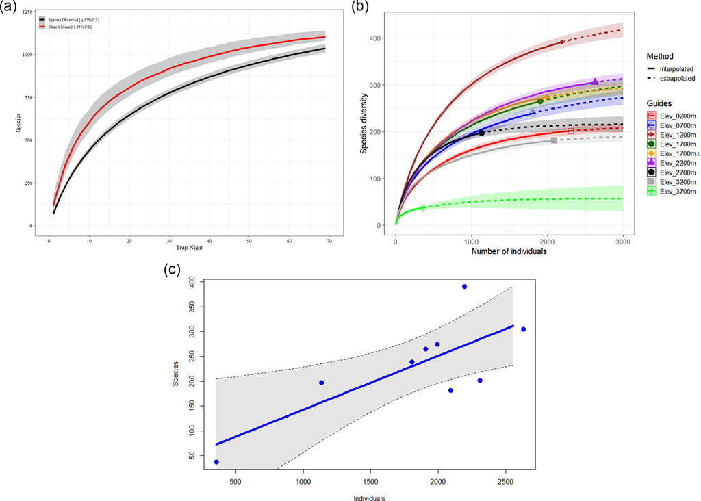

**FIGURE 1**

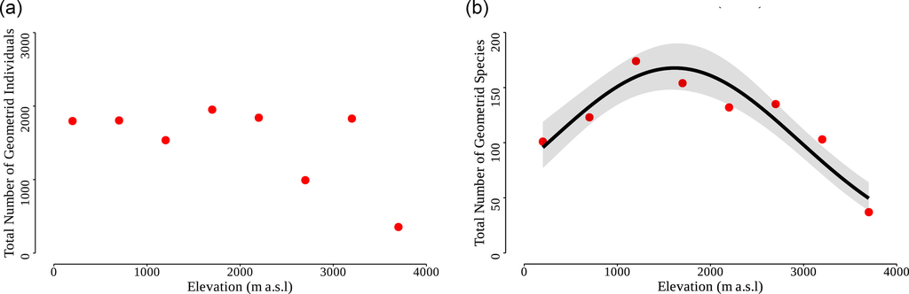

**FIGURE 2**

The elevational trends in geometrid abundance per seven sampling nights (a) and species richness per 355 individuals (b). The correlation with elevation is not significant for abundance, while the number of geometrid species is best fitted by a second order polynomial with Poisson distribution (Species = Elevation + I(Elevation2) + season) (*p* < 0.01).

The relative importance of individual subfamilies, both in terms of the number of species and individuals, changed with elevation (Figure S3). The share of Sterrhinae and Geometrinae decreased and that of Larentiinae increased with increasing elevation, while the most abundant subfamily Ennominae exhibited a mid-elevation maximum for the number of individuals and a constant share of species diversity across elevations.

Similarity between geometrid communities decreased with the logarithm of their elevation distance, with all pairs of communities separated by >1000 m elevation having Bray Curtis similarity <0.15 (Figure S4). The main driver of beta diversity is species turnover, which on average accounts for 92% of total beta diversity across all pairwise comparisons between elevation sites.

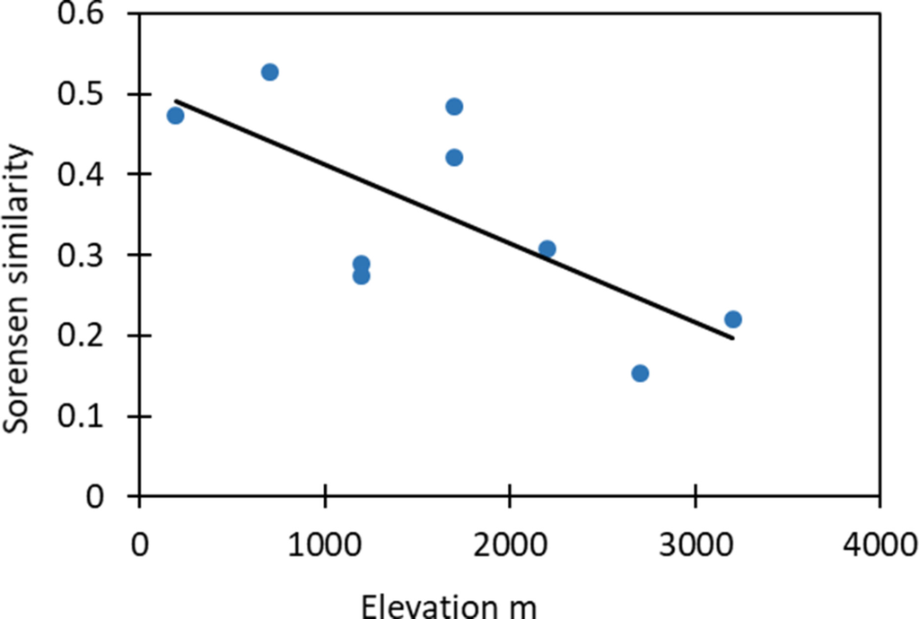

**FIGURE 3**

Sorensen similarity between pairs of adjacent sites separated by 500 m elevation difference (Pearson *r* = − 0.71, *p* = 0.031). The elevation of the lower site is used for each similarity value.

The decreasing similarity of communities with elevation is a consequence of the parallel trend of decreasing mean elevational range of species in the geometrid communities. When mean elevational range is weighted by species abundance, it decreases from 1264 m at 200 m asl. to 633 m at 3700 m asl. This trend also holds for the mean elevational range based on the presence/absence of species (Figure 4).

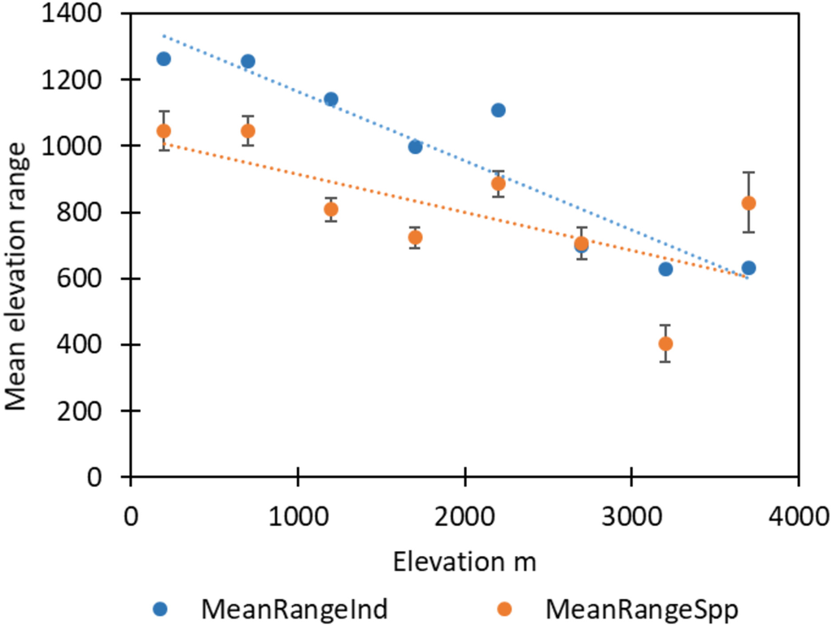

**FIGURE 4**

The relationship between mean elevational range for individuals (Pearson *r* = −0.94, *p* < 0.05) and species (Pearson *r* = −0.68, *p* < 0.05, based on species sampled as ≥10 individuals) and elevation.

Elevation trends in basal area and number of species for woody plants, which represent a potential resource base for herbivorous geometrids, show an approximately unimodal response to elevation, but with maxima at different elevations: at 1200 m asl. for species and at 2700 m asl. for basal area (Figure 5). Thus, there is broad agreement between trends in plant and geometrid species richness, but not between plant basal area and geometrid abundance. Predation pressure, measured as the abundance and species diversity of insectivorous birds, bats and ants shows a largely monotonic decrease with increasing elevation (Figure 5).

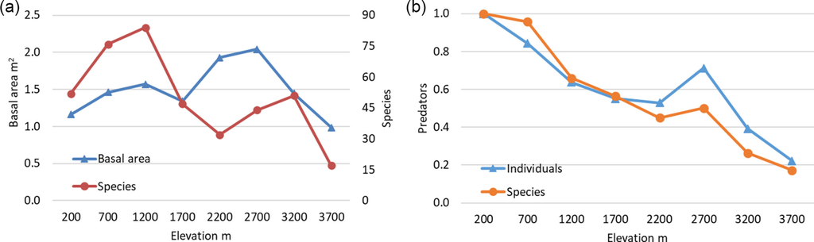

**FIGURE 5**

(a) Elevational trends in basal area (in m<sup>2</sup>) and number of species per 1200 m<sup>2</sup> for woody plants with DBH ≥5 cm. (b) Elevation trends in the relative number of predatory species and individuals, calculated as mean values for insectivorous birds, insectivorous bats and ants standardised to the (0, 1) range.

Geometrid abundance was not significantly correlated with elevation and could not be explained by any combination of mean annual temperature, predator abundance and plant basal area (Table S1). Geometrid species richness was best explained by plant species richness (Table S1). Geometrid community species composition was partially explained by temperature, predator abundance and plant species composition. The three significant variables accounted for 38.7% of the total variability in species composition (*F* = 1.4, *p* < 0.05, Monte Carlo test) (Figure 6).

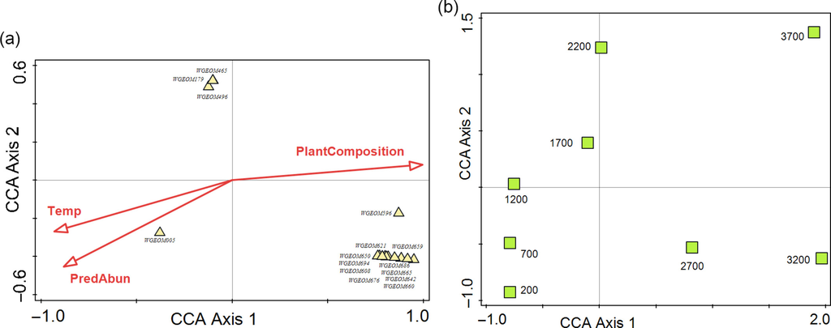

**FIGURE 6**

## DISCUSSION

Our Mt. Wilhelm dataset recorded one of the highest geometrid diversities along a rainforest elevation gradient (Beck et al., 2017), surpassed only by elevational gradients in the Andes (Beck et al., 2017; Brehm et al., 2005; Holloway et al., 2009). The diversity of herbivorous Geometridae may depend in part on vascular plant diversity, which reaches one of six global maxima in the Mt. Wilhelm area (Kier et al., 2005), although the plant-geometrid correlation may be weakened by an increasing role of ‘alternative feeders’, specialising on epiphylls, lichens, and dead leaves in montane forests (Bodner et al., 2015).

On the Mt. Wilhelm transect, butterfly and bird diversity decreased with increasing elevation, while ants and ferns exhibited a peak at mid-elevation (Colwell et al., 2016). A peak in species richness at mid-elevation, between 600 and 1700 m asl. in the tropics, is the most common pattern for geometrids (Beck & Chey, 2008; Beck et al., 2017; Brehm et al., 2005; but see Brehm, Süssenbach, & Fiedler, 2003). This is a robust pattern that is not influenced by anthropogenic disturbance, geographic region, or climate (Beck et al., 2017). The diversity peak may shift within a few hundred metres of elevation depending on seasonality (Beck et al., 2010; Maicher et al., 2019), but this was likely not the case in our study system.

A global analysis by Beck et al. (2017) showed that there is no obvious single variable explaining the nearly universal mid-elevation maximum in geometrid diversity. Even multivariate models, when successful, provided idiosyncratic explanations for some of the data sets, with some support for variables such as primary productivity and land area, temperature, and the mid-domain effect (Beck et al., 2017; Evans et al., 2005; Maicher et al., 2019; McCain, 2007). Multi-taxa analyses of other moth families have found that temperature is an important driver of diversity (Bärtschi et al., 2019; McCain, 2007, 2009; Peters et al., 2016). In addition, primary productivity is important because it determines the diversity of food resources (Evans & Gaston, 2005).

The relationship between plant and geometrid diversity is complicated by the variable host specificity of geometrid species and the fact that many plant lineages do not host geometrid herbivores (Holloway, 1993, 1996, 1997; Novotny et al., 2002). While some studies found no correlation between plant richness or basal area and geometrid species diversity (Axmacher, Holtmann, et al., 2004; Axmacher, Tünte, et al., 2004; Axmacher et al., 2009), plant species richness at Mt. Wilhelm was the best explanatory variable for geometrid species richness, while plant composition partly explained species composition of geometrids.

A mid-elevation maximum may also result from a combination of monotonic factors acting in opposite directions, such as decreasing energy density and area size versus decreasing predation pressure with increasing elevation. Predation pressure measured more directly as attack rates on dummy caterpillars decreased with elevation at Mt. Wilhelm (Sam et al., 2015) and globally (Roslin et al., 2017). Beck and Chey (2008) tested five variables using segmented regression, thus drawing different sets of explanatory variables for the upward and downward trends in species richness along the transect. This is a promising approach, but their analyses lacked data on predation, while our data are limited to only eight elevations.

As expected, community similarity decreased as a logarithmic function of elevation distance among study sites (Brehm, Homeier, & Fiedler, 2003). The rapid species turnover contrasts with low beta diversity over distances within the lowland rainforests of New Guinea (Novotny et al., 2007). The mean elevational range of geometrid species decreased with elevation, a pattern contrary to that expected under Rapoport's rule (Stevens, 1992). Rapaport's rule suggests that high temperature variability leads to greater temperature tolerance in high-elevation species and thus their greater elevational ranges. Beck et al. (2016) confirmed this relationship between temperature variability and geographic range size for geometrids but noted that temperature variability does not necessarily increase with elevation in the tropics.

The increasing species turnover across 500 m elevation with increasing elevation refutes the hypothesis that the peak in alpha diversity at mid-elevation is caused by mixing of two different species groups—lowland and montane, as this would lead to a peak in beta diversity at mid-elevation (Beck & Chey, 2008). Beta diversity has generally been determined by species change rather than nestedness. This is expected for successive replacement of individual lineages, such as subfamilies, with elevation.

The total of 1102 species found along the transect represents 280% of the highest local diversity recorded at 1200 m asl. This is the third highest transect-to-community ratio among taxa surveyed along the Mt. Wilhelm gradient (Novotny & Toko, 2015), highlighting the key role of elevational gradients in maintaining high regional diversity. This species enrichment makes long elevation gradients in the tropics priority areas for biodiversity conservation. Mt. Wilhelm National Park includes only 800 ha of alpine ecosystems, representing a small minority of all species along the entire gradient. Based on recent biodiversity surveys, including this study, an expanded protected area is proposed (Novotny & Toko, 2015). Protecting continuous, long elevation gradients is increasingly important because they allow species to redistribute in response to climate change.

## AUTHOR CONTRIBUTIONS

**Pagi S. Toko:** Conceptualization; methodology; data curation; investigation; formal analysis; visualization; project administration; writing – original draft; writing – review and editing. **Bonny Koane:** Investigation. **Kenneth Molem:** Investigation; methodology; data curation. **Scott E. Miller:** Conceptualization; methodology; data curation; investigation; validation; formal analysis; resources; writing – review and editing. **Vojtech Novotny:** Conceptualization; methodology; supervision; formal analysis; funding acquisition; visualization; project administration; writing – review and editing.

## ACKNOWLEDGEMENTS

We thank the staff of New Guinea Binatang Research Center for logistical support during the field work; the landowners along the Mt Wilhelm transect for their forests; A. Hausmann and J.D. Holloway for taxonomic advice and J. Moses and P. Szefer for biostatistical advice. DNA sequencing was provided by the Canadian Centre for DNA Barcoding, University of Guelph, through the iBOL project, funded by Genome Canada and others, and also supported by the National Museum of Natural History, Smithsonian Institution. We thank Jeremy de Waard, Laruen Helgen, Margaret Rosati, Talitta Simoes, David Pollock, and Nicholas Silverson for their assistance with DNA barcodes.

## FUNDING INFORMATION

This work was funded by Czech Science Foundation grant 19-28126X to Vojtech Novotny.

## CONFLICT OF INTEREST STATEMENT

The author declares that there is no conflict of interest for any author.

[figure not shown]